# tmplate

- **Name**: `Transforming1`
- **Fully Qualified Name**: `org.openprovenance.templates.generic.Transforming1`
- **IRI**: https://openprovenance.org/templates/org/openprovenance/templates/generic/Transforming1
- **Purpose**: The template `Transforming1` describes the transformation of an input into an output.
- **Context**: It is intended to be a general form of transformation, with a single input and a single output.
- **Design considerations**: Relations rigorously linking nodes using pre-defined triangles.
- **Automation**: ttfs/config-generic-transforming.json

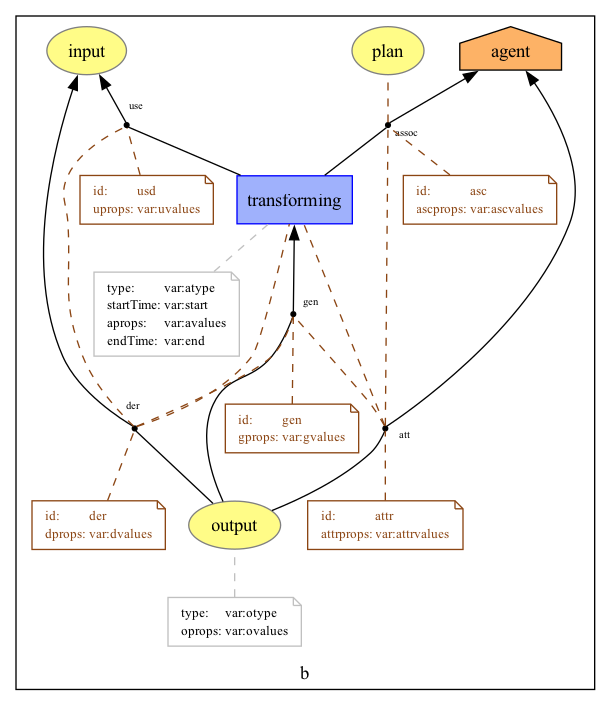

Figure 1: org.openprovenance.templates.generic.Transforming1

- **Details**:

  There are two entities directly related to the transformation: `input` and `output`; an activity `transforming`; an agent `agent`; and an associated plan `plan`. The template is constructed by instantiating two templates:
  - The template Triangle1-Entity-UGD links the output to the input by means of a derivation, underpinned by the activity `transforming`, which used the input and generated the output.
  - The template Triangle2-Entity-AGA introduces an agent (and a plan), which is associated with the activity and bears responsibility for the generated output.